Tyler Pollard, Rachel Hardy, and Hanan Ali 2024-05-06

- Motivation
- Data
  - Spatial Structure
  - Temporal Structure
- Model Description
  - Data Preprocessing
  - Model Specification

# Motivation

Coral bleaching occurs when corals experience stress due to changes in environmental conditions such as temperature, light, or nutrient levels. This stress leads corals to expel their symbiotic algae, resulting in the loss of their coloration and, in severe cases, coral death.

Several factors contribute to coral bleaching, including rising sea temperatures, sea-level changes, and ocean acidification, all of which are consequences of climate change. Understanding the key environmental drivers of bleaching is critical for conservation efforts.

The objective of this study is to identify and quantify the **impact of key environmental covariates on coral bleaching** while also assessing **how bleaching has changed over time** across different locations in Florida. Using **spatiotemporal modeling**, we analyze trends in coral bleaching by incorporating both **spatial variation** (reef locations) and **temporal patterns** (yearly changes) within a **Bayesian regression framework**.

# Data

| Covariate | Description |
| --- | --- |
| Date_Year | Year of observation |
| City_Town_Name | Categorical variable representing the specific city or town |
| Lat | Latitude of the coral reef transect |
| Lon | Longitude of the coral reef transect |
| Distance_to_Shore | Distance from the reef to the shoreline (km) |
| Exposure | Level of wave exposure (e.g., sheltered, exposed) |
| Turbidity | Water clarity, with higher values indicating more suspended particles |
| Cyclone_Frequency | Number of cyclones affecting the area per year |
| Depth_m | Depth of the coral reef (meters) |
| Windspeed | Average wind speed (m/s) |
| ClimSST | Climatological sea surface temperature (°C) |
| SSTA | Sea surface temperature anomaly (°C) |
| SSTA_DHW | Degree heating weeks derived from SSTA |
| TSA | Tropical sea surface temperature anomaly (°C) |
| TSA_DHW | Degree heating weeks derived from TSA |

| **Covariate** | **Description** |
| --- | --- |
| **Date_Year** | Year of observation |
| **Lat** | Latitude of the coral reef transect |
| **Lon** | Longitude of the coral reef transect |
| **Distance_to_Shore** | Distance from the reef to the shoreline (km) |
| **Exposure** | Level of wave exposure (e.g., sheltered, exposed) |
| **Turbidity** | Water clarity, with higher values indicating more suspended particles |
| **Cyclone_Frequency** | Number of cyclones affecting the area per year |
| **Depth_m** | Depth of the coral reef (meters) |
| **Windspeed** | Average wind speed (m/s) |
| **ClimSST** | Climatological sea surface temperature (°C) |
| **SSTA** | Sea surface temperature anomaly (°C) |
| **SSTA_DHW** | Degree heating weeks derived from SSTA |
| **TSA** | Tropical sea surface temperature anomaly (°C) |
| **TSA_DHW** | Degree heating weeks derived from TSA |
| **City_Town_Name** | Categorical variable representing the specific city or town |

The Percent Bleaching data exhibits a right-skewed distribution (Figure 1), with a substantial number of observations reporting 0% bleaching.

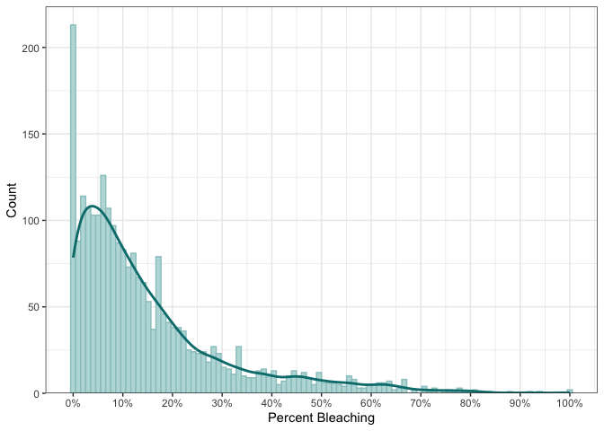

Figure 1: Density Plot of Percent Bleaching from 2,394 Coral Reef Samples

## Spatial Structure

Coral bleaching observations were **geographically distributed across Florida’s reef systems** (Figure 2). Mapping Percent Bleaching reveals **spatial clustering**, with certain areas experiencing more severe bleaching than others.

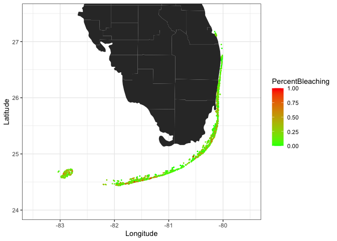

Figure 2: Map of Percent Bleaching from 2,394 Coral Reef Samples around Florida

## Temporal Structure

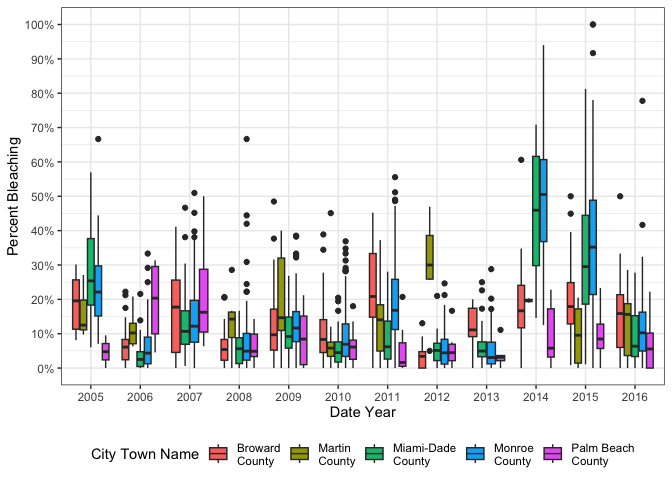

Figure 3: Boxplots of Percent Bleaching vs Year by City Town Name

# Model Description

## Data Preprocessing

Before fitting the model, we applied several preprocessing steps:

- **Response Variable Transformation**: Since the Beta regression model requires values strictly in the (0,1) range, we replaced:
  - 0% bleaching values with 0.001
  - 100% bleaching values with 0.999
- **Covariate Transformations**:
  - **Yeo-Johnson transformation** was applied to all continuous covariates to reduce skewness.
  - **Centering and scaling** were performed to standardize covariates for better model convergence.

## Model Specification

To model the proportion of coral bleaching $Y_i$, we use a **Bayesian Beta regression** with a **logit link function**:

$$\begin{aligned}
Y_i \sim \text{Beta}(\mu_i \phi, (1-\mu_i) \phi)
\end{aligned}$$